# Assigment 5: Dimensionality reduction techniques

## PCA

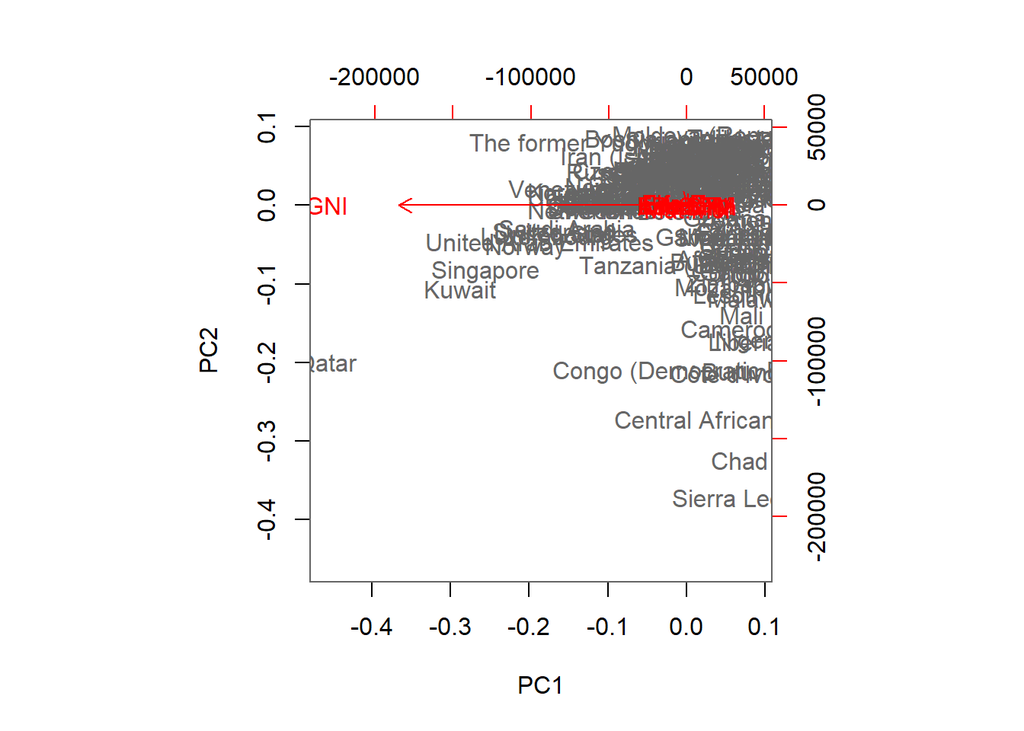

```r
pca_human= prcomp(human)
biplot(pca_human, choices = 1:2, cex=c(1, 1), col=c("grey40", "red"))
```

Without standardisation differnet scales makes graph impossible to read. Maximum value of GNI is so large, it dwarfs all other variables. Such we must standardize the variables.

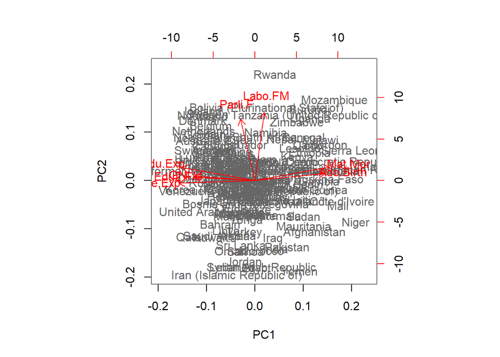

```r
human_std= scale(human)
pca_human_std= prcomp(human_std)
biplot(pca_human_std, choices = 1:2, cex=c(1, 1), col=c("gray40", "red"))
```

After standardization the graph is easier to interpret. Labo.FM has greatest effect on PC2. It is harder to say witch variable has greatest effect on PC1, perhaps edu.exp.  
There are 3 separate groups. labo.fm and paril.F create the first group. They correlated but they are not correlated to any other variable. Variables Mat.Mor and Ado.Birth are correlated and create group 2. Group 3 is composed of the rest of variables. Variables in group 2 and 3 are negative correlated. This means that in countries with high education and high income decreases Maternal Mortality Ratio and Adolescent Birth Rate. In other words, those decrease as welfare increases. Group 1 suggests that Labor Force Participation Rate and female percent Representation in Parliament has little to do with income and education. Thus PC1 represents welfare (or as high welfare is in negative it represents the hardship). And PC2 represents variables that don’t have correlation with that. PC2 could be more about equality. High % of labor suggests all genders are actively working outside home and high precent of females in parliament suggests that they females are active operators in society.

## MCA

```r
tea = read.csv("https://raw.githubusercontent.com/KimmoVehkalahti/Helsinki-Open-Data-Science/master/datasets/tea.csv", stringsAsFactors = TRUE)
str(tea)
```

```
## 'data.frame':    300 obs. of  36 variables:
##  $ breakfast       : Factor w/ 2 levels "breakfast","Not.breakfast": 1 1 2 2 1 2 1 2 1 1 ...
##  $ tea.time        : Factor w/ 2 levels "Not.tea time",..: 1 1 2 1 1 1 2 2 2 1 ...
##  $ evening         : Factor w/ 2 levels "evening","Not.evening": 2 2 1 2 1 2 2 1 2 1 ...
##  $ lunch           : Factor w/ 2 levels "lunch","Not.lunch": 2 2 2 2 2 2 2 2 2 2 ...
##  $ dinner          : Factor w/ 2 levels "dinner","Not.dinner": 2 2 1 1 2 1 2 2 2 2 ...
##  $ always          : Factor w/ 2 levels "always","Not.always": 2 2 2 2 1 2 2 2 2 2 ...
##  $ home            : Factor w/ 2 levels "home","Not.home": 1 1 1 1 1 1 1 1 1 1 ...
##  $ work            : Factor w/ 2 levels "Not.work","work": 1 1 2 1 1 1 1 1 1 1 ...
##  $ tearoom         : Factor w/ 2 levels "Not.tearoom",..: 1 1 1 1 1 1 1 1 1 2 ...
##  $ friends         : Factor w/ 2 levels "friends","Not.friends": 2 2 1 2 2 2 1 2 2 2 ...
##  $ resto           : Factor w/ 2 levels "Not.resto","resto": 1 1 2 1 1 1 1 1 1 1 ...
##  $ pub             : Factor w/ 2 levels "Not.pub","pub": 1 1 1 1 1 1 1 1 1 1 ...
##  $ Tea             : Factor w/ 3 levels "black","Earl Grey",..: 1 1 2 2 2 2 2 1 2 1 ...
##  $ How             : Factor w/ 4 levels "alone","lemon",..: 1 3 1 1 1 1 1 3 3 1 ...
```

[output cut: 22 more lines]

```r
dim(tea)
```

```
## [1] 300  36
```

```r
View(tea)
```

Lets see of there are NA values

```r
unique(is.na(tea))
```

```
##      breakfast tea.time evening lunch dinner always  home  work tearoom friends
## [1,]     FALSE    FALSE   FALSE FALSE  FALSE  FALSE FALSE FALSE   FALSE   FALSE
##      resto   pub   Tea   How sugar   how where price   age   sex   SPC Sport
## [1,] FALSE FALSE FALSE FALSE FALSE FALSE FALSE FALSE FALSE FALSE FALSE FALSE
##      age_Q frequency escape.exoticism spirituality healthy diuretic
## [1,] FALSE     FALSE            FALSE        FALSE   FALSE    FALSE
##      friendliness iron.absorption feminine sophisticated slimming exciting
## [1,]        FALSE           FALSE    FALSE         FALSE    FALSE    FALSE
##      relaxing effect.on.health
## [1,]    FALSE            FALSE
```

no Na values

```r
library(FactoMineR)
```

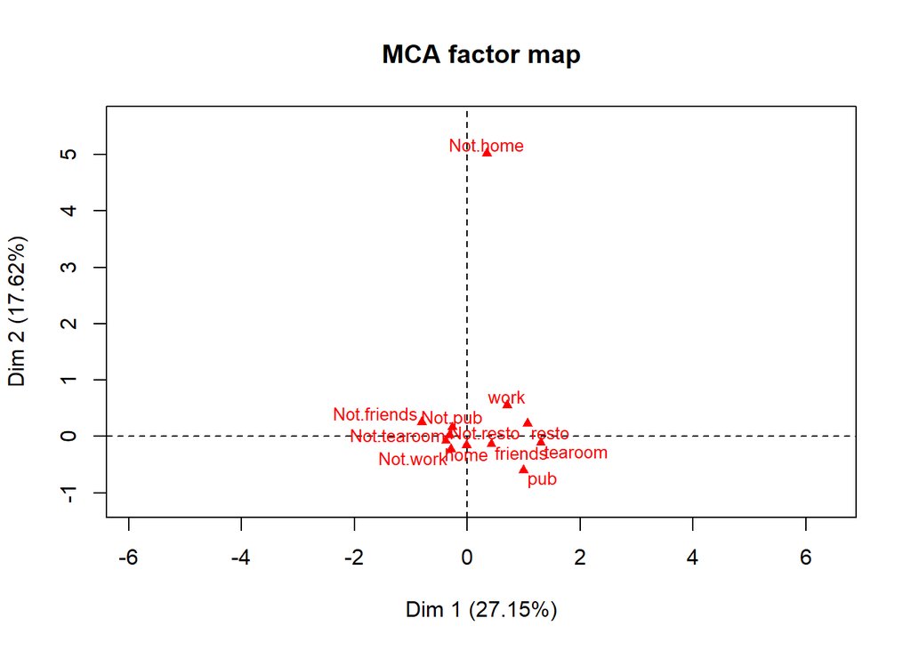

```r
keep=c("home", "work", "tearoom", "friends", "resto", "pub")
tea_loc_sex= select(tea, one_of(keep))
mca <- MCA(tea_loc_sex, graph = FALSE)
plot(mca, invisible=c("ind"), graph.type = "classic", cex=0.8)
```

I chose variables that represent where tea is consumed. It seems that people taht consume tea, consume it everywhere( work, restaurants, tearooms, pubs etc.). How ever it is interesting that “not home” variable has little correlation to other “not” answers. It seems that dimension 1 is more about “do you drink tea”, but not home is clearly an outlier, as all other not-answers are bellow zero on dimension 1. Lets try other ploting options!

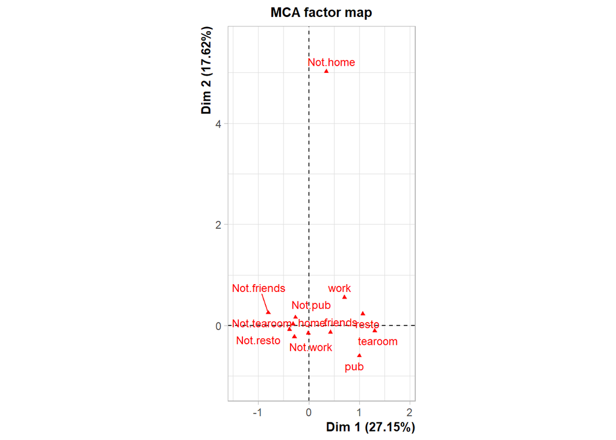

```r
plot(mca, invisible=c("ind"), graph.type = "ggplot", cex=0.8)
```

Using ggplot option, the graph is a lot clearer as the texts do not overlap as much.

That’s all folks!

…